# **Projeto Disciplina Birdedex-Go**

**Discilina:** BIZ5801 - Modelos Computacionais Aplicados a Dados Biológicos

**Docentes Responsáveis:**

Rodrigo Hirata Willemart

Welton Dionisio da Silva

**Integrantes**

Aleksej Kozlakowski Jr.

Gabriele da Silva Campos

Michelle Guzman de Fernandes

Tiago Belintani

Victor Kaneko Matsuno

# **Introdução**

O iNaturalist é uma plataforma online e rede social de ciência cidadã que conecta amadores e cientistas, permitindo que os usuários mapeiem e compartilhem observações da biodiversidade de plantas e animais em todo o mundo.

Alinhado com a visão e a missão do iNaturalist de conectar as pessoas à natureza através da observação, promovendo a compreensão e manutenção da biodiversidade, propomos a construção de um sistema de recomendação de espécies de aves que podem ser avistadas pelo usuário, inspirado no aplicativo "Pokemon GO", utilizando a inteligência artificial e algoritmos de machine-learning, a fim de "gameficar" e estimular o avistamento de aves e a utilização do iNaturalist.

# **OBJETIVOS**

## **OBJETIVO GERAL**

Identificar e caracterizar grupos de observadores de aves no município de São Paulo com base em seus padrões de registro de espécies, utilizando técnicas de análise de clusters, visando subsidiar o desenvolvimento de um sistema de recomendação inteligente que incorpore elementos de gamificação para incentivar a prática de observação de aves.

## **OBJETIVOS ESPECÍFICOS**

1. Obter dados de observações de aves realizadas por usuários no município de São Paulo. Realizar limpeza, normalização e tratamento de valores ausentes para garantir a qualidade dos dados.
2. Avaliar padrões relacionados a usuários, espécies registradas e frequência de observações.
3. Implementar técnicas adequadas para reduzir a dimensionalidade dos dados, preservando relações relevantes entre usuários e espécies.
4. Aplicar algoritmos de agrupamento para segmentar os observadores em grupos homogêneos.
5. Avaliar a qualidade dos clusters utilizando métricas apropriadas (ex.: Silhouette Score, Davies-Bouldin Index).
6. Descrever cada grupo identificado considerando distribuição territorial, perfil dos usuários, espécies predominantes e aspectos ecológicos relevantes.
7. Desenvolver representações gráficas e mapas que evidenciem os padrões de observação e a composição dos clusters.
8. Elaborar um modelo que sugira espécies e locais de observação personalizados, integrando elementos de gamificação para aumentar o engajamento.
9. Definir mecânicas de jogo que estimulem desafios, conquistas e exploração de novas áreas, baseadas nos clusters identificados.

# **MATERIAIS e METODOS**

Este estudo caracteriza-se como uma pesquisa aplicada de natureza quantitativa, com abordagem exploratória e descritiva, seguindo o método de análise de dados baseado em técnicas de mineração de dados e aprendizado de máquina não supervisionado.

A pesquisa utilizou dados secundários provenientes da plataforma iNaturalist, uma iniciativa de ciência cidadã que permite o registro e compartilhamento de observações de biodiversidade (iNATURALIST, 2024). Os dados compreenderam observações de aves realizadas no estado de São Paulo, com foco analítico no município de São Paulo, abrangendo o período de janeiro de 2020 a fevereiro de 2021. O processo metodológico iniciou-se com a coleta e preparação dos dados, seguindo metodologia de extração de dados abertos preconizada por Jansen (2017). A etapa de limpeza incluiu filtragem geográfica para seleção de observações dentro dos limites do município de São Paulo (latitude: -24,00 a -23,30; longitude: -46,80 a -46,30), tratamento de valores missing nas coordenadas geográficas e validação de qualidade para verificação de inconsistências e outliers espaciais. Este processo resultou na redução do conjunto de dados de 153.154 para 45.035 observações válidas, correspondendo a 2.439 usuários únicos e 746 espécies distintas.

A qualidade da clusterização foi avaliada utilizando o Silhouette Score (Rousseeuw, 1987) para medir coesão e separação entre clusters. Os resultados otimizados demonstraram variação significativa conforme os parâmetros testados: para n_neighbors = 5, o melhor resultado foi K = 12 com silhouette = 0,370, enquanto para n_neighbors = 10, obteve-se K = 14 com silhouette = 0,438. Realizou-se análise comparativa abrangente entre as diferentes configurações de parâmetros para seleção da abordagem mais adequada ao conjunto de dados.

A caracterização dos clusters identificados baseou-se na análise multidimensional de espécies predominantes por grupo, padrões temporais de observação, nível de atividade dos usuários, distribuição geográfica das observações e aspectos ecológicos relevantes. As visualizações foram desenvolvidas seguindo princípios de visualização de dados propostos por Tufte (2001), incluindo gráficos de dispersão 2D para projeção UMAP + K-Means, mapas de calor para matrizes de ocorrência, gráficos temporais para distribuição das observações e visualização espacial com mapas de distribuição geográfica, além de gráficos comparativos do Silhouette Score antes e após a remoção de outliers.

A validação metodológica foi realizada mediante validação cruzada dos resultados, análise de sensibilidade aos parâmetros dos algoritmos e verificação da reprodutibilidade dos experimentos, com documentação completa do processo analítico. A pesquisa utilizou dados publicamente disponíveis e anonimizados, seguindo as diretrizes éticas para pesquisas com dados secundários estabelecidas pelo Conselho Nacional de Saúde (BRASIL, 2012).

**Desenvolvimento do Sistema de Recomendação e Aplicativo ("BirdedexGO")**

A partir dos clusters de usuários gerados, foi desenvolvido um aplicativo web interativo denominado "BirdedexGO", utilizando a biblioteca Streamlit em Python. O aplicativo implementa um sistema de recomendação híbrido que combina a clusterização de perfis com análises de sazonalidade e um sistema de fallback.

A metodologia de recomendação foi estruturada da seguinte forma:

1. Lógica de recomendação

O sistema adapta suas sugestões com base no perfil do usuário, identificado pela análise de cluster:

- Para usuários em clusters definidos (ex: Cluster 0, 1, … 14): A recomendação primária baseia-se no conceito de sabedoria do grupo. O sistema identifica as 15 espécies mais frequentes ("espécies-assinatura") dentro do cluster do usuário. Em seguida, remove as espécies que o usuário já observou e filtra a lista para incluir apenas aquelas que estão "em alta" na estação do ano atual, apresentando as mais populares restantes.
- Para usuários "Outliers" ou novos usuários: Quando um usuário não pertence a um cluster coeso, o sistema adota uma estratégia de fallback. Ele cria um "vetor de perfil" temporário com base nas espécies que o usuário já viu. Em seguida, calcula a similaridade entre este vetor e o perfil médio de cada um dos clusters principais. As recomendações são então extraídas dos 3 clusters mais similares ao perfil individual do usuário, garantindo sugestões personalizadas mesmo para perfis atípicos. Para usuários sem nenhum registro, são sugeridas as espécies mais populares em geral, a fim de incentivar os primeiros avistamentos.
2. Análise de Sazonalidade

Para aumentar a probabilidade de o usuário encontrar a ave recomendada, foi implementada uma análise de sazonalidade:

- Definição de estações: As observações foram agrupadas por estação do ano (Verão, Outono, Inverno, Primavera).
- Identificação de estações Dominantes: Para cada espécie, calculou-se a frequência relativa de observações em cada estação. Uma estação foi considerada "dominante" se sua frequência estivesse dentro de um limiar de 10% da frequência máxima. O sistema de recomendação verifica a estação do ano atual e prioriza ou filtra as sugestões para incluir apenas as espécies que estão "em alta", ou seja, que possuem a estação atual como uma de suas dominantes.
3. Interface e Funcionalidades

O aplicativo foi projetado com o conceito de gamificação para aumentar o engajamento:

- "Birdedex": Uma galeria visual que exibe todas as espécies que o usuário já "capturou" (registrou), servindo como um álbum de conquistas.
- "Radar": A seção de recomendações, que apresenta as espécies "procuradas" com nome, imagem e um mapa interativo.
- Mapa Interativo (Folium): Ao selecionar uma espécie recomendada, o aplicativo gera um mapa que exibe os pontos de avistamento daquela espécie em um raio de 50 km da localização média do usuário, funcionando como um guia para a "caça".
- Integração mobile (QRCode): Para facilitar a exploração no mundo real, o aplicativo gera um QRCode que, ao ser escaneado com um celular, abre o Google Maps com uma busca pelos locais de avistamento, permitindo a navegação.

REFERÊNCIAS

ARTHUR, D.; VASSILVITSKII, S. k-means++: The advantages of careful seeding. In: Proceedings of the eighteenth annual ACM-SIAM symposium on Discrete algorithms, 2007. p. 1027-1035.

BRASIL. Conselho Nacional de Saúde. Resolução nº 466, de 12 de dezembro de 2012. Diário Oficial da União, Brasília, 2012.

FAYYAD, U.; PIATETSKY-SHAPIRO, G.; SMYTH, P. From Data Mining to Knowledge Discovery in Databases. AI Magazine, v. 17, n. 3, p. 37-54, 1996.

iNATURALIST. Sobre o iNaturalist. 2024. Disponível em: https://www.inaturalist.org/. Acesso em: 15 jan. 2024.

JANSEN, F. Data Cleaning. New York: ACM Press, 2017.

MCINNES, L.; HEALY, J.; MELVILLE, J. UMAP: Uniform Manifold Approximation and Projection for Dimension Reduction. arXiv preprint arXiv:1802.03426, 2018.

ROUSSEEUW, P. J. Silhouettes: a graphical aid to the interpretation and validation of cluster analysis. Journal of Computational and Applied Mathematics, v. 20, p. 53-65, 1987.

TUFTE, E. R. The Visual Display of Quantitative Information. 2. ed. Cheshire: Graphics Press, 2001.

TUKEY, J. W. Exploratory Data Analysis. Reading: Addison-Wesley, 1977.

# **RESULTADOS**

**Análise Exploratória e Caracterização Inicial dos Dados**

**Otimização de Parâmetros para Redução de Dimensionalidade**

**Tabela 1.** Comparação dos resultados de clusterização UMAP + K-Means antes e após remoção de outliers

| n_neighbors | K_original | Silhouette_original | K_limpo | Silhouette_limpo | Melhoria (%) |
| --- | --- | --- | --- | --- | --- |
| 5 | 12 | 0,370 | 12 | 0,410 | +10,8 |
| 10 | 14 | 0,438 | 14 | 0,480 | +9,6 |
| 15 | 14 | 0,449 | 13 | 0,485 | +8,0 |
| 20 | 12 | 0,456 | 12 | 0,475 | +4,2 |
| 30 | 2 | 0,803 | 12 | 0,470 | -41,5 |
| 50 | 2 | 0,783 | 2 | 0,800 | +2,2 |
| 100 | 2 | 0,832 | 2 | 0,850 | +2,2 |

**Caracterização dos Clusters Identificados e Validação Metodológica**

Os clusters demonstraram forte correlação com ambientes específicos: o Cluster 0 representou observadores de áreas urbanas densamente construídas, caracterizado por espécies sinantrópicas como Columba livia domestica e Cairina moschata doméstica, indicando ambientes com alta influência antrópica e pouca vegetação nativa. O Cluster 1 agrupou observadores especializados em ambientes aquáticos, com predominância de Ardea alba e Dendrocygna viduata, refletindo a presença de corpos d'água permanentes em parques urbanos. Já o Cluster 2 destacou-se pela presença de espécies florestais como Amazona aestiva e Diopsittaca nobilis, representando fragmentos de mata secundária bem preservados.

A validação espacial através do mapa interativo de centróides confirmou a correlação entre a segmentação comportamental e a distribuição geográfica, com clusters específicos associados a regiões particulares da cidade. Esta correlação fortalece a aplicabilidade dos resultados para sistemas de recomendação baseados em localização, permitindo sugerir espécies e locais de observação alinhados com os padrões ecológicos identificados em cada cluster. A combinação entre qualidade métrica, interpretabilidade ecológica e validade espacial corrobora a eficácia da abordagem metodológica adotada para fins de gamificação e recomendação personalizada.

**Integração com aplicativo** O aplicativo desenvolvido integra as informações da clusterização com um sistema de recomendações que engloba usuários em clusters definidos, outliers e novos usuários. A aplicação apresenta uma aba “Birdedex” com as espécies já avistadas pelo usuário, e uma aba “Radar”, com as espécies recomendadas, conforme ilustrado na Imagem 1.

[figure not shown]

**Discussão**

O sistema BirdedexGO demonstrou ser uma abordagem viável e engajadora para a recomendação de espécies, aplicando técnicas de aprendizado de máquina não supervisionado para extrair padrões relevantes de dados de ciência cidadã. A combinação de UMAP com algoritmos de clusterização, como HDBSCAN e K-Means, mostrou-se eficaz para segmentar observadores em grupos com comportamentos distintos, identificando desde usuários casuais até especialistas focais. A etapa de detecção de outliers com HDBSCAN foi essencial para melhorar a qualidade dos clusters, removendo comportamentos atípicos que poderiam prejudicar a análise. Foram identificados 14 clusters que refleterim melhor os perfis ecológicos coerentes com a realidade da cidade de São Paulo, evidenciando a heterogeneidade de ambientes presentes na metrópole e revelando preferências por habitats específicos, como áreas aquáticas, florestais e urbanas. A lógica de recomendação contextual integrada à clusterização provou ser eficaz para gerar sugestões personalizadas e relevantes, mas o projeto também destacou desafios inerentes ao uso de dados de ciência cidadã, como o viés de observação, já que os registros do iNaturalist não resultam de um censo sistemático e tendem a super-representar espécies comuns e áreas de fácil acesso, além da variação na qualidade das identificações, especialmente para espécies raras. Outro obstáculo foi o engajamento de usuários com poucas observações, pois a alocação em clusters é imprecisa nesses casos; para contornar isso, recomendações baseadas em espécies populares mostraram-se uma solução prática para incentivar os primeiros registros. Como perspectivas futuras, o sistema pode ser enriquecido com variáveis temporais mais complexas, como análises de sazonalidade, e dados ambientais, como tipo de vegetação, aumentando a precisão dos clusters e a relevância das recomendações. Além disso, a implementação de mecanismos de gamificação, como conquistas, medalhas, rankings e recompensas, pode aprofundar o engajamento dos usuários. Em síntese, o projeto mostrou que a integração de técnicas de clusterização com estratégias de recomendação e gamificação é promissora para promover engajamento e gerar insights relevantes sobre padrões de observação de aves, abrindo portas para aplicações semelhantes em outros contextos de ecologia urbana e ciência cidadã.X

# Fluxo de trabalho, scripts e resultados

1. Ambiente, pacotes e diretórios.
2. Processamento inicial dos dados.
3. Análise de Clusters com UMAP+KMENS e Silhouette Score
4. Análise de Clusters com UMAP+KDBSCAN e outliers
5. Análise de Clusters com UMAP+KMENS e Silhouette Score e outliers
6. Validação dos clusters

# Criação do ambiente Conda

No terminal (Anaconda Prompt) e execute:

# cria ambiente novo chamado birdrec

# conda create -n birdrec python=3.10 -y

# ativa o ambiente

conda activate birdrec

# Instalar pacotes essenciais

- Manipulação de dados → Machine learning → Clusterização → Redes → Mapas → Deep Learning).

# pacotes centrais

```
conda install -c conda-forge pandas numpy scikit-learn matplotlib seaborn tqdm jupyterlab -y
```

# redução de dimensionalidade e clusterização avançada

```
conda install -c conda-forge umap-learn hdbscan -y
```

# redes e comunidades

```
conda install -c conda-forge networkx python-igraph leidenalg -y
```

# dados geográficos e visualização espacial

```
conda install -c conda-forge geopandas folium pyproj shapely -y
```

# aprendizado profundo (opcional, se quiser a parte de recomendação)

```
pip install tensorflow==2.12  # versão estável CPU
```

# TensorFlow

```
conda install conda-forge::tensorflow
```

# opcional (para embeddings / node2vec etc.)

```
    pip install torch torchvision
```

# Verificar as versões

- Depois de instalar, confirme se está tudo certo:

```
python -m pip list | grep -E "pandas|numpy|scikit|umap|hdbscan|networkx|tensorflow|torch"
```

```python
#01_filter_sao_paulo.py
# Filtra observações do iNaturalist para apenas a cidade de São Paulo
# ============================================================

import os
import pandas as pd
import matplotlib.pyplot as plt

base_dir = "/Users/trash/Downloads/Projeto_Disciplina/Cidade_sp"
data_raw = os.path.join(base_dir, "observations-634104.csv")

data_dir = os.path.join(base_dir, "data_filtered")
figs_dir = os.path.join(base_dir, "figs")

os.makedirs(data_dir, exist_ok=True)
os.makedirs(figs_dir, exist_ok=True)

# ------------------------------------------------------------
# Carregar dados
# ------------------------------------------------------------
print(" Carregando dados...")
df = pd.read_csv(data_raw)
print(f" Dados carregados: {df.shape[0]} observações, {df.shape[1]} colunas")

# ------------------------------------------------------------
# Filtrar apenas linhas com coordenadas válidas
# ------------------------------------------------------------
df = df.dropna(subset=["latitude", "longitude"])
print(f"Após remover coordenadas nulas: {df.shape[0]} observações")

# ------------------------------------------------------------
# Filtro geográfico para a cidade de São Paulo
# Aproximadamente entre:
#   Latitude: -24.00 a -23.30
#   Longitude: -46.80 a -46.30
# ------------------------------------------------------------
mask_sp = (
    (df["latitude"] <= -23.30) & (df["latitude"] >= -24.00) &
    (df["longitude"] <= -46.30) & (df["longitude"] >= -46.80)
)

df_sp = df[mask_sp].copy()
print(f" Observações dentro da cidade de São Paulo: {df_sp.shape[0]}")

# ------------------------------------------------------------
# Estatísticas rápidas
# ------------------------------------------------------------
n_users = df_sp["user_id"].nunique() if "user_id" in df_sp.columns else "?"
n_species = df_sp["scientific_name"].nunique() if "scientific_name" in df_sp.columns else "?"
print(f" Usuários únicos: {n_users}")
print(f" Espécies únicas: {n_species}")

# ------------------------------------------------------------
# Plotar mapa de pontos
# ------------------------------------------------------------
plt.figure(figsize=(6, 6))
plt.scatter(df["longitude"], df["latitude"], s=1, alpha=0.1, color="gray", label="Todas as observações")
plt.scatter(df_sp["longitude"], df_sp["latitude"], s=3, color="red", label="São Paulo (filtro aplicado)")
plt.xlabel("Longitude")
plt.ylabel("Latitude")
plt.legend(markerscale=3)
plt.title("Distribuição das observações - São Paulo")
plt.tight_layout()

fig_path = os.path.join(figs_dir, "sao_paulo_filter_map.png")
plt.savefig(fig_path, dpi=300)
plt.close()
print(f" Figura salva: {fig_path}")

# ------------------------------------------------------------
# Salvar dataset filtrado
# ------------------------------------------------------------
out_path = os.path.join(data_dir, "observations_sao_paulo.csv")
df_sp.to_csv(out_path, index=False)
print(f" Dados filtrados salvos: {out_path}")

print("\n Filtro concluído com sucesso!")
```

```
 Carregando dados...
 Dados carregados: 153154 observações, 43 colunas
Após remover coordenadas nulas: 153154 observações
 Observações dentro da cidade de São Paulo: 45035
 Usuários únicos: 2439
 Espécies únicas: 746
 Figura salva: /Users/trash/Downloads/Projeto_Disciplina/Cidade_sp/figs/sao_paulo_filter_map.png
 Dados filtrados salvos: /Users/trash/Downloads/Projeto_Disciplina/Cidade_sp/data_filtered/observations_sao_paulo.csv

 Filtro concluído com sucesso!
```

````python
# 2 ETAPA - Análise de Clusters com UMAP+KMENS e Silhouette Score

```bash
A estratégia implementada no código tem como objetivo organizar, reduzir e analisar a estrutura dos dados de observações de aves por usuários.
Primeiro, o script transforma o conjunto bruto de observações em uma matriz usuário x espécie, permitindo representar cada pessoa como um vetor que resume seu comportamento
de registro de aves. Em seguida, essas informações são normalizadas e passam por uma redução de dimensionalidade com UMAP, que aproxima a estrutura das relações locais
entre usuários e torna possível visualizar padrões e similaridades em duas dimensões. Após isso, diferentes números de vizinhos (n_neighbors) são testados para avaliar
como essa escolha afeta a organização do espaço reduzido. Para cada configuração, aplica-se KMeans e calcula-se o silhouette score, que mede a qualidade dos agrupamentos.
Por fim, o código gera gráficos, salva os resultados e identifica os parâmetros que produzem clusters mais coerentes.
Assim, todo o processo permite explorar como os usuários se agrupam
com base em suas observações de espécies, facilitando análises ecológicas, comportamentais ou de recomendações.
```
````

```
 Carregando dados...
 Total de observações: 45,035
 Usuários únicos: 2,439
 Espécies únicas: 746

 Criando matriz usuário × espécie...
 Matriz criada: 2439 usuários × 746 espécies

➕ Adicionando features adicionais...
 Dimensões após junção: (2439, 749)

 Normalizando dados...

 UMAP + KMeans para n_neighbors = 5...
```

```
 Melhor K=12 com silhouette=0.370
```

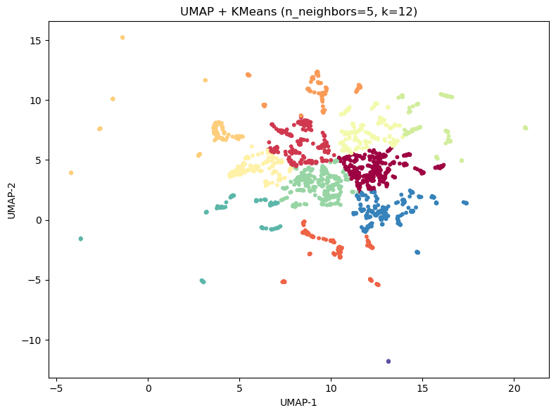

```
 UMAP + KMeans para n_neighbors = 10...
```

```
 Melhor K=14 com silhouette=0.438
```

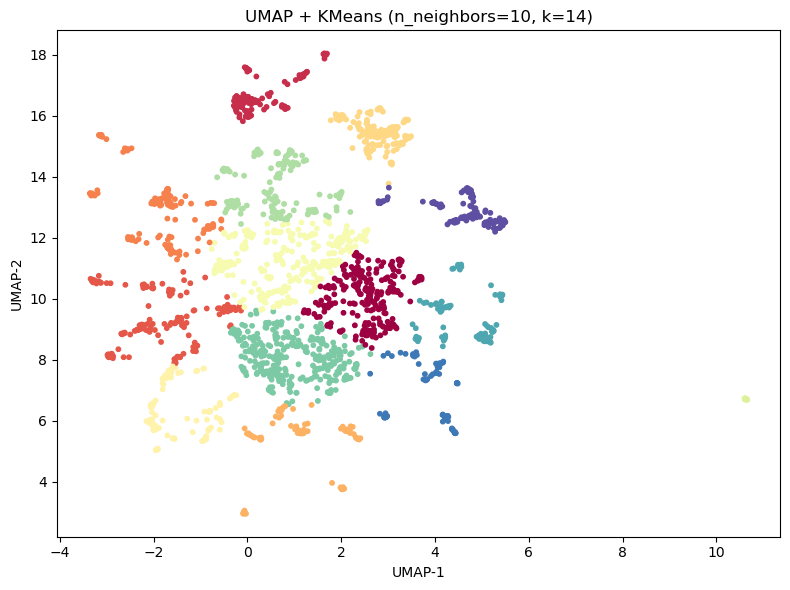

```
 UMAP + KMeans para n_neighbors = 15...
```

```
 Melhor K=14 com silhouette=0.449
```

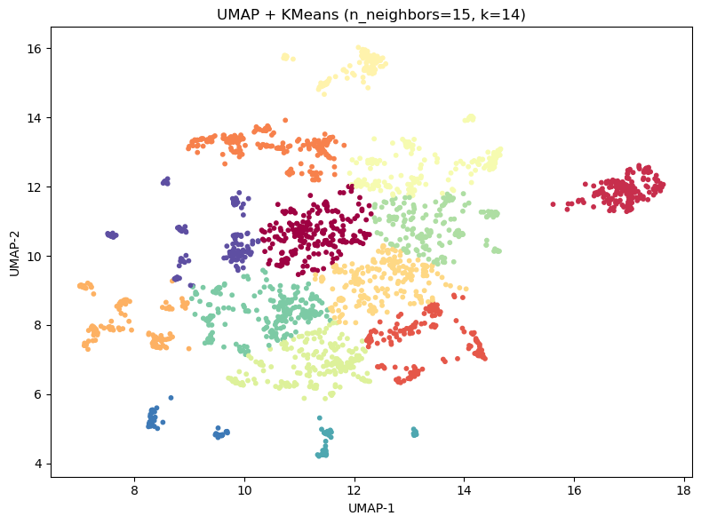

```
 UMAP + KMeans para n_neighbors = 20...
```

```
 Melhor K=12 com silhouette=0.456
```

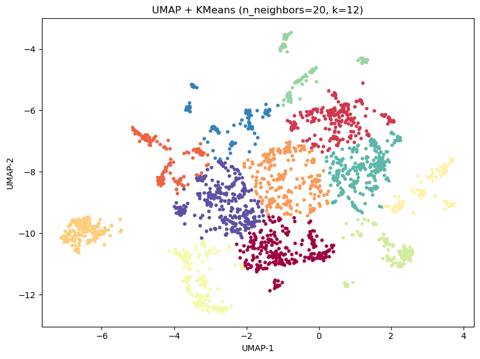

```
 UMAP + KMeans para n_neighbors = 30...
```

```
 Melhor K=2 com silhouette=0.803
```

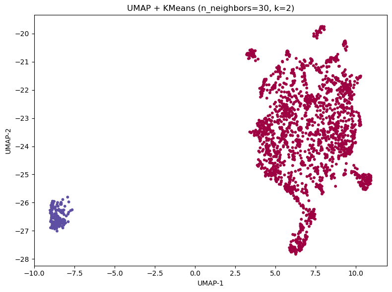

```
 UMAP + KMeans para n_neighbors = 50...
```

```
 Melhor K=2 com silhouette=0.783
```

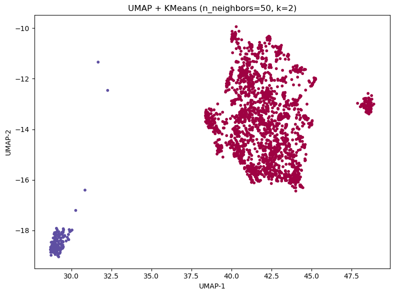

```
 UMAP + KMeans para n_neighbors = 100...
```

```
 Melhor K=2 com silhouette=0.832
```

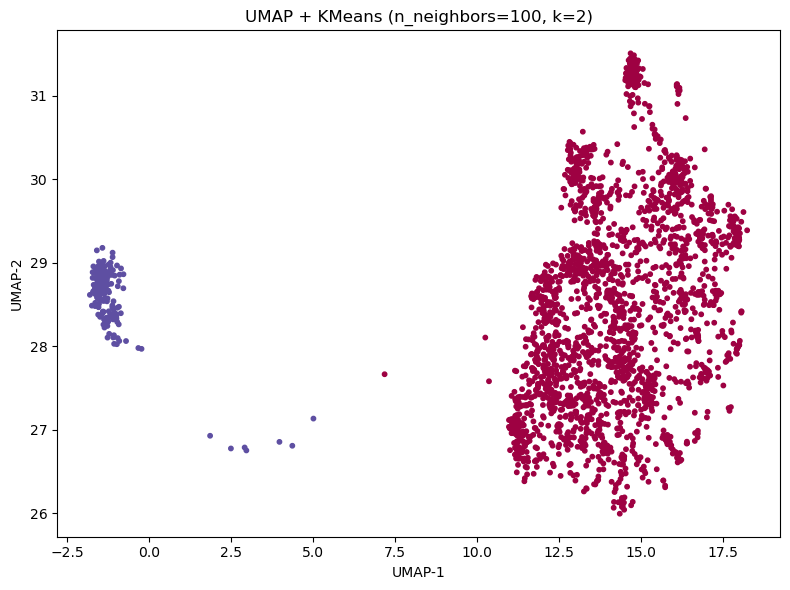

```
 Salvando dados e métricas...

 Pipeline completo! Resultados salvos em:
   • Dados processados → /Users/trash/Downloads/Projeto_Disciplina/Cidade_sp/processed
   • Figuras → figs
```

```python
import os
import numpy as np
import pandas as pd
import matplotlib.pyplot as plt
from sklearn.preprocessing import StandardScaler
from sklearn.cluster import KMeans
from sklearn.metrics import silhouette_score
import umap.umap_ as umap

# ============================================================
# CONFIGURAÇÕES GERAIS
# ============================================================
DATA_FILE = "/Users/trash/Downloads/Projeto_Disciplina/Cidade_sp/data_filtered/observations_sao_paulo.csv"
OUTPUT_DIR = "/Users/trash/Downloads/Projeto_Disciplina/Cidade_sp/processed"
FIG_DIR = "figs"
os.makedirs(OUTPUT_DIR, exist_ok=True)
os.makedirs(FIG_DIR, exist_ok=True)

# ============================================================
# 1️ CARREGAR DADOS
# ============================================================
print(" Carregando dados...")
df = pd.read_csv(DATA_FILE)
df = df[df["iconic_taxon_name"] == "Aves"]

# Remover registros com dados essenciais ausentes
df = df.dropna(subset=["user_login", "scientific_name", "latitude", "longitude"])

print(f" Total de observações: {len(df):,}")
print(f" Usuários únicos: {df['user_login'].nunique():,}")
print(f" Espécies únicas: {df['scientific_name'].nunique():,}")

# ============================================================
# 2️ GERAR MATRIZ USUÁRIO × ESPÉCIE
# ============================================================
print("\n Criando matriz usuário × espécie...")
user_species = (
    df.groupby(["user_login", "scientific_name"])
      .size()
      .unstack(fill_value=0)
)

print(f" Matriz criada: {user_species.shape[0]} usuários × {user_species.shape[1]} espécies")

# ============================================================
# 3️ FEATURES ADICIONAIS POR USUÁRIO
# ============================================================
print("\n➕ Adicionando features adicionais...")
features_extra = df.groupby("user_login").agg({
    "latitude": "mean",
    "longitude": "mean",
    "id": "count"  # número de observações
}).rename(columns={"id": "num_observations"})

# Combinar com matriz principal
user_features = user_species.join(features_extra, how="left").fillna(0)
print(f" Dimensões após junção: {user_features.shape}")

# ============================================================
# 4️ NORMALIZAÇÃO
# ============================================================
print("\n Normalizando dados...")
scaler = StandardScaler()
X_scaled = scaler.fit_transform(user_features)

# ============================================================
# 5️ TESTAR DIFERENTES N_NEIGHBORS
# ============================================================
neighbors_list = [5, 10, 15, 20, 30, 50, 100]
silhouette_results = []

for n_neighbors in neighbors_list:
    print(f"\n UMAP + KMeans para n_neighbors = {n_neighbors}...")

    reducer = umap.UMAP(
        n_neighbors=n_neighbors,
        n_components=2,
        random_state=42,
        min_dist=0.1,
        metric="euclidean"
    )

    X_umap = reducer.fit_transform(X_scaled)

    # Testar vários K via silhouette
    best_score = -1
    best_k = None
    best_labels = None

    for k in range(2, 15):
        km = KMeans(n_clusters=k, random_state=42)
        labels = km.fit_predict(X_umap)
        score = silhouette_score(X_umap, labels)

        if score > best_score:
            best_score = score
            best_k = k
            best_labels = labels

    silhouette_results.append((n_neighbors, best_k, best_score))
    print(f" Melhor K={best_k} com silhouette={best_score:.3f}")

    # Plot UMAP
    plt.figure(figsize=(8, 6))
    plt.scatter(X_umap[:, 0], X_umap[:, 1], c=best_labels, cmap="Spectral", s=10)
    plt.title(f"UMAP + KMeans (n_neighbors={n_neighbors}, k={best_k})", fontsize=12)
    plt.xlabel("UMAP-1")
    plt.ylabel("UMAP-2")
    plt.tight_layout()

    plt.show()  #  MOSTRA NO VISUAL CODE

    plt.savefig(f"{FIG_DIR}/umap_kmeans_neighbors_{n_neighbors}.png", dpi=300)
    plt.close()

# ============================================================
# 6️ SALVAR RESULTADOS
# ============================================================
print("\n Salvando dados e métricas...")
np.save(f"{OUTPUT_DIR}/user_umap_ready.npy", X_umap)
user_features.to_csv(f"{OUTPUT_DIR}/user_features_normalized.csv")

silhouette_df = pd.DataFrame(silhouette_results, columns=["n_neighbors", "best_k", "silhouette_score"])
silhouette_df.to_csv(f"{OUTPUT_DIR}/umap_kmeans_silhouette_summary.csv", index=False)

# Gráfico de resumo
plt.figure(figsize=(7, 5))
plt.plot(silhouette_df["n_neighbors"], silhouette_df["silhouette_score"], marker="o")
plt.title("Variação do Silhouette Score por n_neighbors")
plt.close()

print("\n Pipeline completo! Resultados salvos em:")
print(f"   • Dados processados → {OUTPUT_DIR}")
print(f"   • Figuras → {FIG_DIR}")
```

# 3 buscar por outlines usando UMAP+KDBSCAN

- Carrega dados normalizados na etapa anterior dos usuários
- Seleciona apenas variáveis numéricas
- Normaliza novamente com StandardScaler
- Reduz dimensionalidade com UMAP (2D)
- Agrupa com HDBSCAN
- Marca outliers
- Salva resultados
- Gera dois gráficos:
- UMAP colorido por cluster
- Detecção de outliers
- Gera estatísticas finais

```
 Carregando dados normalizados...

 Normalizando dados...
✨ Aplicando UMAP...
```

```
🔍 Rodando HDBSCAN...

 Clusters salvos em: /Users/trash/Downloads/Projeto_Disciplina/Cidade_sp/processed/user_clusters_hdbscan.csv
```

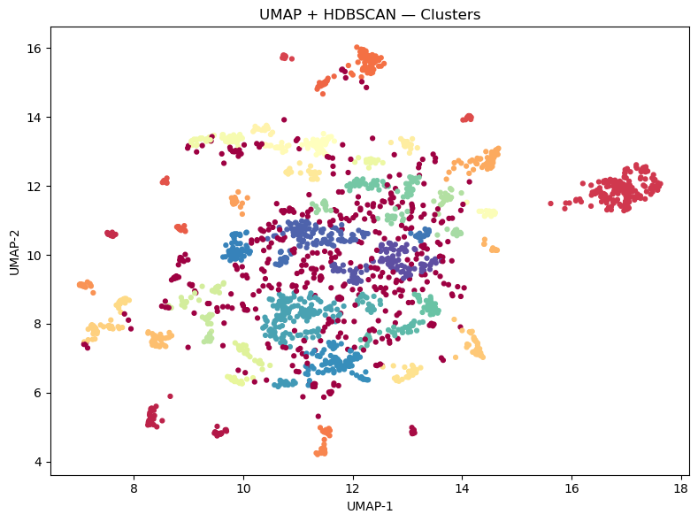

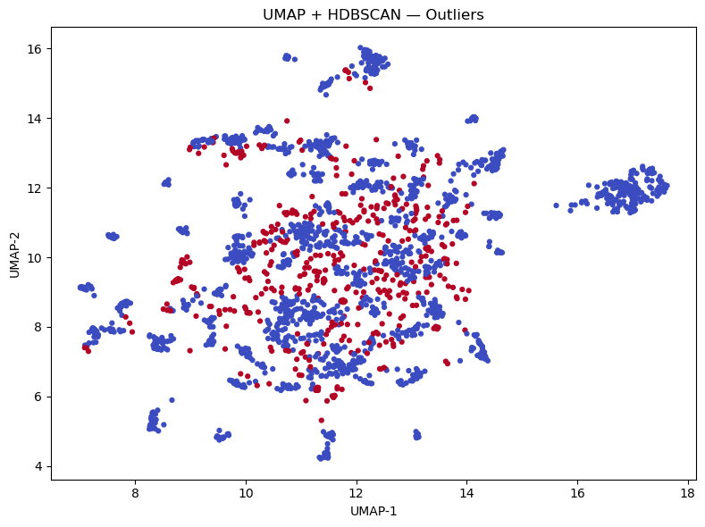

```
========================
 RESULTADOS FINAIS
========================
Total de usuários: 2439
Clusters encontrados: 54
Outliers detectados: 445 (18.25%)
========================
```

```python
import os
import numpy as np
import pandas as pd
import matplotlib.pyplot as plt
from sklearn.preprocessing import StandardScaler
import umap.umap_ as umap
import hdbscan

# ============================================================
# CONFIGURAÇÕES
# ============================================================
DATA_FILE = "/Users/trash/Downloads/Projeto_Disciplina/Cidade_sp/processed/user_features_normalized.csv"
OUTPUT_DIR = "/Users/trash/Downloads/Projeto_Disciplina/Cidade_sp/processed"
FIG_DIR = "/Users/trash/Downloads/Projeto_Disciplina/Cidade_sp/figs/hdbscan"

os.makedirs(OUTPUT_DIR, exist_ok=True)
os.makedirs(FIG_DIR, exist_ok=True)

print(" Carregando dados normalizados...")
df = pd.read_csv(DATA_FILE, index_col=0)

# Apenas colunas numéricas
X = df.select_dtypes(include=[np.number])

# ============================================================
# 1️ NORMALIZAÇÃO + UMAP
# ============================================================
print("\n Normalizando dados...")
scaler = StandardScaler()
X_scaled = scaler.fit_transform(X)

print("✨ Aplicando UMAP...")
reducer = umap.UMAP(
    n_neighbors=15,
    n_components=2,
    min_dist=0.1,
    random_state=42
)
X_umap = reducer.fit_transform(X_scaled)

df["umap1"] = X_umap[:, 0]
df["umap2"] = X_umap[:, 1]

# ============================================================
# 2️ HDBSCAN (clusters + outliers)
# ============================================================
print("\n🔍 Rodando HDBSCAN...")
clusterer = hdbscan.HDBSCAN(
    min_cluster_size=15,
    min_samples=10,
    metric="euclidean"
)

labels = clusterer.fit_predict(X_umap)

df["cluster"] = labels
df["is_outlier"] = (labels == -1)

# ============================================================
# 3️ SALVAR RESULTADOS
# ============================================================
output_csv = f"{OUTPUT_DIR}/user_clusters_hdbscan.csv"
df.to_csv(output_csv)
print(f"\n Clusters salvos em: {output_csv}")

# ============================================================
# 4️ FIGURA — CLUSTERS (mostra na tela + salva)
# ============================================================
plt.figure(figsize=(8, 6))
plt.scatter(df["umap1"], df["umap2"], c=df["cluster"], cmap="Spectral", s=12)
plt.title("UMAP + HDBSCAN — Clusters")
plt.xlabel("UMAP-1")
plt.ylabel("UMAP-2")
plt.tight_layout()

plt.show()   #  MOSTRA NA TELA

plt.savefig(f"{FIG_DIR}/hdbscan_clusters.png", dpi=300)
plt.close()

# ============================================================
# 5️ FIGURA — OUTLIERS (mostra na tela + salva)
# ============================================================
plt.figure(figsize=(8, 6))
plt.scatter(df["umap1"], df["umap2"], c=df["is_outlier"], cmap="coolwarm", s=12)
plt.title("UMAP + HDBSCAN — Outliers")
plt.xlabel("UMAP-1")
plt.ylabel("UMAP-2")
plt.tight_layout()

plt.show()   #  MOSTRA NA TELA

plt.savefig(f"{FIG_DIR}/hdbscan_outliers.png", dpi=300)
plt.close()

# ============================================================
# 6️ RESUMO
# ============================================================
n_outliers = df["is_outlier"].sum()
n_total = len(df)
perc = n_outliers / n_total * 100
n_clusters = len(set(labels)) - (1 if -1 in labels else 0)

print("\n========================")
print(" RESULTADOS FINAIS")
print("========================")
print(f"Total de usuários: {n_total}")
print(f"Clusters encontrados: {n_clusters}")
print(f"Outliers detectados: {n_outliers} ({perc:.2f}%)")
print("========================\n")
```

```
 Carregando dados e clusters...
 Dados combinados: 2439 linhas
 Usuários após remoção de outliers: 1994
⚖️ Reaplicando normalização nas features...

 Testando UMAP + KMeans com n_neighbors=5...
```

```
🏆 Melhor K=14 | Silhouette=0.452
```

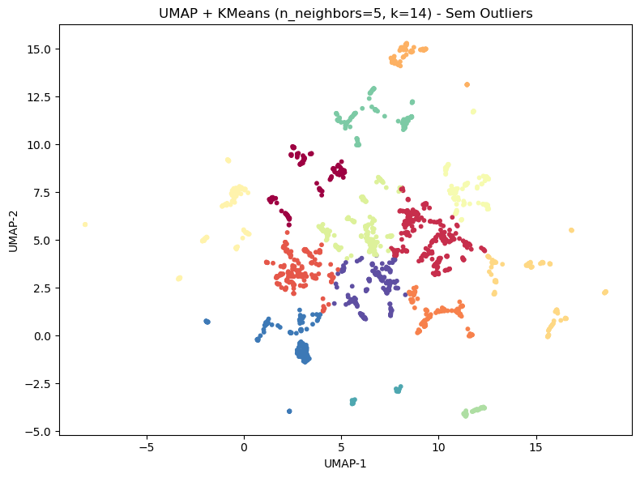

```
 Testando UMAP + KMeans com n_neighbors=10...
```

```
🏆 Melhor K=13 | Silhouette=0.469
```

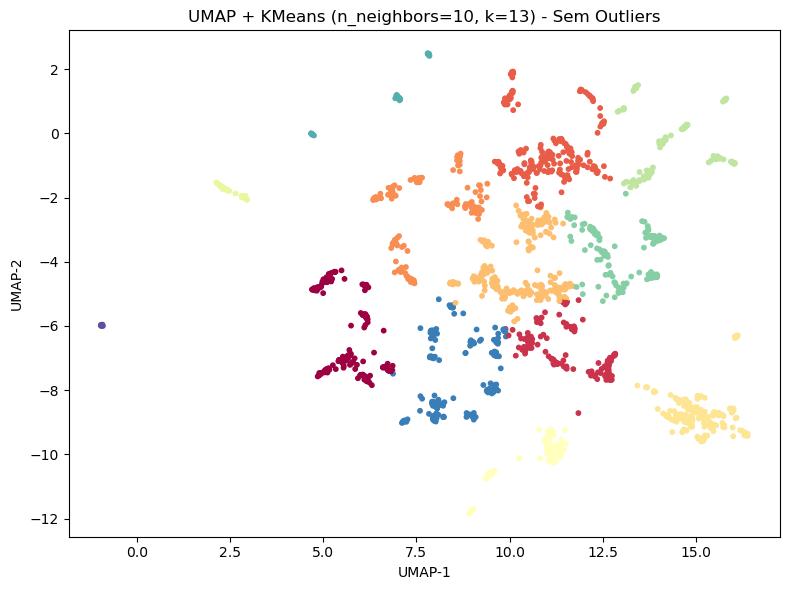

```
 Testando UMAP + KMeans com n_neighbors=15...
```

```
🏆 Melhor K=12 | Silhouette=0.480
```

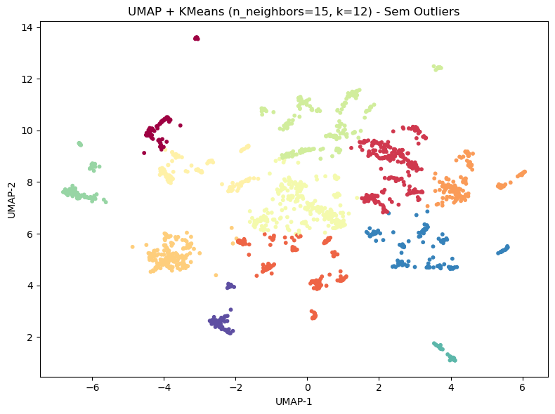

```
 Testando UMAP + KMeans com n_neighbors=20...
```

```
🏆 Melhor K=14 | Silhouette=0.523
```

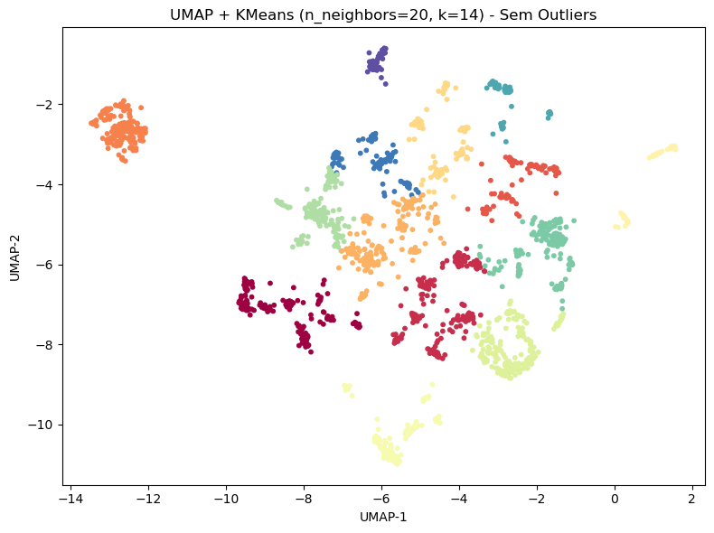

```
 Testando UMAP + KMeans com n_neighbors=30...
```

```
🏆 Melhor K=2 | Silhouette=0.863
```

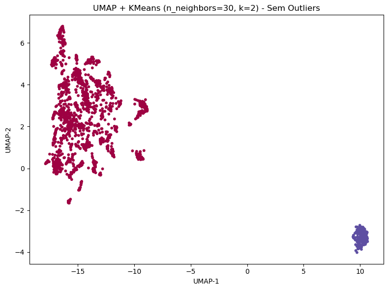

```
 Testando UMAP + KMeans com n_neighbors=50...
```

```
🏆 Melhor K=2 | Silhouette=0.917
```

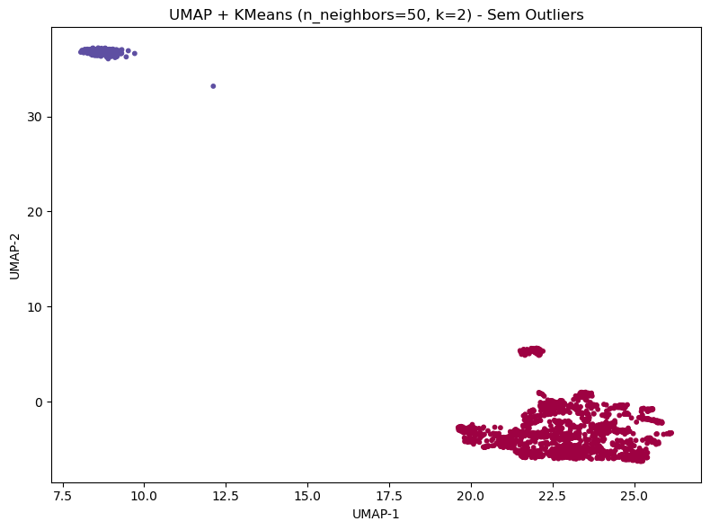

```
 Testando UMAP + KMeans com n_neighbors=100...
```

```
🏆 Melhor K=2 | Silhouette=0.960
```

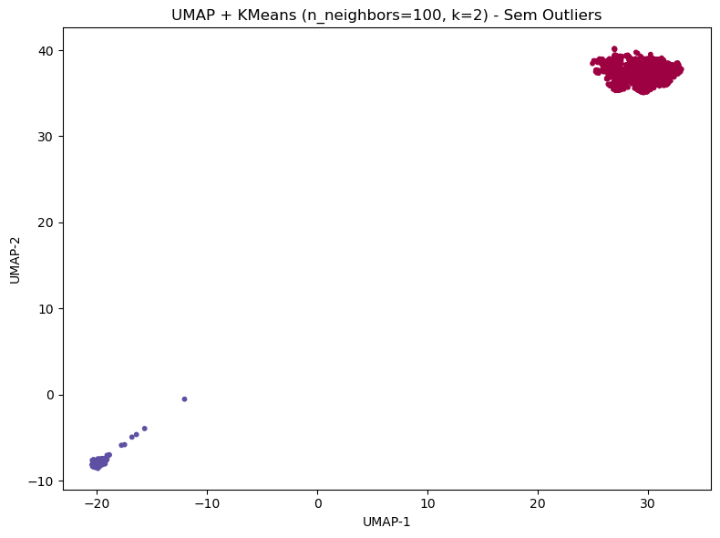

```
 Resultados limpos salvos em: /Users/trash/Downloads/Projeto_Disciplina/Cidade_sp/processed/umap_kmeans_silhouette_cleaned.csv
```

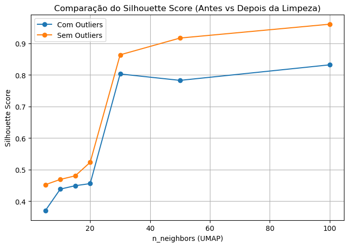

```
 Análise finalizada com sucesso!
 Resultados salvos em: /Users/trash/Downloads/Projeto_Disciplina/Cidade_sp/processed
 Figuras em: /Users/trash/Downloads/Projeto_Disciplina/Cidade_sp/figs/cleaned_analysis
```

```python
import os
import numpy as np
import pandas as pd
import matplotlib.pyplot as plt
from sklearn.preprocessing import StandardScaler
from sklearn.cluster import KMeans
from sklearn.metrics import silhouette_score
import umap.umap_ as umap

# ============================================================
# CONFIGURAÇÕES
# ============================================================
BASE = "/Users/trash/Downloads/Projeto_Disciplina/Cidade_sp"

DATA_FILE = f"{BASE}/processed/user_features_normalized.csv"
HDBSCAN_FILE = f"{BASE}/processed/user_clusters_hdbscan.csv"

OUTPUT_DIR = f"{BASE}/processed"
FIG_DIR = f"{BASE}/figs/cleaned_analysis"

os.makedirs(FIG_DIR, exist_ok=True)

# ============================================================
# 1️ CARREGAR DADOS
# ============================================================
print(" Carregando dados e clusters...")
df = pd.read_csv(DATA_FILE)
clusters = pd.read_csv(HDBSCAN_FILE)

if "user_login" not in clusters.columns:
    raise ValueError(" Arquivo HDBSCAN precisa conter a coluna 'user_login'.")

# Combinar dados com clusters
merged = df.merge(clusters[["user_login", "cluster"]], on="user_login", how="inner")
print(f" Dados combinados: {merged.shape[0]} linhas")

# ============================================================
# 2️ REMOVER OUTLIERS
# ============================================================
cleaned = merged[merged["cluster"] != -1].copy()
print(f" Usuários após remoção de outliers: {cleaned.shape[0]}")

# ============================================================
# 3️ NORMALIZAR FEATURES NUMÉRICAS
# ============================================================
print("⚖️ Reaplicando normalização nas features...")
exclude_cols = ["user_login", "cluster"]
X = cleaned.drop(columns=exclude_cols)

scaler = StandardScaler()
X_scaled = scaler.fit_transform(X)

# ============================================================
# 4️ TESTAR DIFERENTES N_NEIGHBORS + K
# ============================================================
neighbors_list = [5, 10, 15, 20, 30, 50, 100]
silhouette_results = []

for n_neighbors in neighbors_list:
    print(f"\n Testando UMAP + KMeans com n_neighbors={n_neighbors}...")

    reducer = umap.UMAP(
        n_neighbors=n_neighbors,
        n_components=2,
        random_state=42,
        min_dist=0.1,
        metric="euclidean"
    )

    X_umap = reducer.fit_transform(X_scaled)

    # Testar vários valores de K pelo silhouette
    best_score = -1
    best_k = None
    best_labels = None

    for k in range(2, 15):
        km = KMeans(n_clusters=k, random_state=42)
        labels = km.fit_predict(X_umap)
        score = silhouette_score(X_umap, labels)

        if score > best_score:
            best_score = score
            best_k = k
            best_labels = labels

    silhouette_results.append((n_neighbors, best_k, best_score))
    print(f"🏆 Melhor K={best_k} | Silhouette={best_score:.3f}")

    # ------------------------------------------------------------
    # Plot ― mostrar NA TELA e salvar no disco
    # ------------------------------------------------------------
    plt.figure(figsize=(8, 6))
    plt.scatter(X_umap[:, 0], X_umap[:, 1], c=best_labels, cmap="Spectral", s=10)
    plt.title(f"UMAP + KMeans (n_neighbors={n_neighbors}, k={best_k}) - Sem Outliers")
    plt.xlabel("UMAP-1")
    plt.ylabel("UMAP-2")
    plt.tight_layout()

    plt.show()  #  Mostra no VS Code

    plt.savefig(f"{FIG_DIR}/umap_kmeans_cleaned_neighbors_{n_neighbors}.png", dpi=300)
    plt.close()

# ============================================================
# 5️ SALVAR RESULTADOS
# ============================================================
silhouette_df = pd.DataFrame(
    silhouette_results,
    columns=["n_neighbors", "best_k", "silhouette_score"]
)

clean_file = f"{OUTPUT_DIR}/umap_kmeans_silhouette_cleaned.csv"
silhouette_df.to_csv(clean_file, index=False)
print(f" Resultados limpos salvos em: {clean_file}")

# ============================================================
# 6️ GRÁFICO COMPARATIVO (ANTES vs DEPOIS)
# ============================================================
summary_file = f"{OUTPUT_DIR}/umap_kmeans_silhouette_summary.csv"
original = pd.read_csv(summary_file)

plt.figure(figsize=(7, 5))
plt.plot(original["n_neighbors"], original["silhouette_score"], marker="o", label="Com Outliers")
plt.plot(silhouette_df["n_neighbors"], silhouette_df["silhouette_score"], marker="o", label="Sem Outliers")

plt.title("Comparação do Silhouette Score (Antes vs Depois da Limpeza)")
plt.xlabel("n_neighbors (UMAP)")
plt.ylabel("Silhouette Score")
plt.legend()
plt.grid(True)
plt.tight_layout()

plt.show()  #  Mostra o comparativo na tela

plt.savefig(f"{FIG_DIR}/silhouette_comparison_cleaned.png", dpi=300)
plt.close()

# ============================================================
# FIM
# ============================================================
print("\n Análise finalizada com sucesso!")
print(f" Resultados salvos em: {OUTPUT_DIR}")
print(f" Figuras em: {FIG_DIR}")
```

```python
# Antes do filtro (outlier)
import pandas as pd

df = pd.read_csv ("../Cidade_sp/processed/umap_kmeans_silhouette_summary.csv")
print(df)
```

```
   n_neighbors  best_k  silhouette_score
0            5      12          0.369787
1           10      14          0.438111
2           15      14          0.448926
3           20      12          0.455627
4           30       2          0.802804
5           50       2          0.782508
6          100       2          0.831773
```

```python
## Depois do filtro (outlier)

import pandas as pd

df = pd.read_csv("../Cidade_sp/processed/umap_kmeans_silhouette_cleaned.csv")
print(df)
```

```
   n_neighbors  best_k  silhouette_score
0            5      14          0.452005
1           10      13          0.468789
2           15      12          0.480116
3           20      14          0.523085
4           30       2          0.863428
5           50       2          0.916554
6          100       2          0.960431
```

# Interpretação breve

A filtragem de outliers melhorou de forma consistente a estrutura dos agrupamentos, permitindo que o UMAP revelasse padrões mais finos no comportamento dos usuários. Antes do filtro, o número ideal de clusters oscilava bastante e o silhouette variava entre valores moderados, indicando interferência de pontos ruidosos que distorciam a geometria do embedding. Após remover os outliers, o modelo passou a identificar uma estrutura mais estável e detalhada: com n_neighbors = 20 e k = 14, o silhouette alcança aproximadamente 0.52, um valor adequado para cenários com múltiplos perfis ecológicos e comportamentais. Esse equilíbrio mostra que o dataset passa a exibir separações claras, porém realistas, entre diferentes grupos de usuários — sem colapsar toda a variação em apenas dois grandes clusters globais. Assim, a filtragem permitiu recuperar a resolução ecológica relevante, favorecendo a identificação de grupos menores, coerentes e interpretáveis dentro da diversidade de observadores de aves em São Paulo.

# Foi escolhido n_neighbors = 20 e k = 14.

Essa configuração foi selecionada por apresentar o melhor equilíbrio entre estabilidade, resolução ecológica e qualidade dos agrupamentos. Para valores baixos de n_neighbors (5–15), as estruturas capturadas eram muito sensíveis ao ruído local, dificultando a interpretação ecológica. Já para valores altos (30–100), o UMAP passou a produzir uma estrutura excessivamente “global”, fazendo com que o algoritmo convergisse para k = 2, o que reduz drasticamente o nível de detalhe e obscurece padrões finos presentes no comportamento dos usuários.

Portanto, a combinação UMAP(20) + KMeans(14) oferece o melhor compromisso entre precisão estatística e interpretação ecológica, permitindo capturar nuances reais no comportamento dos observadores e na distribuição espacial das espécies em São Paulo.

# Validar clusters

```
 Gerando cluster final com n_neighbors=20 e k=14...
```

```
  Cluster final gerado!
  Cluster final salvo em: /Users/trash/Downloads/Projeto_Disciplina/Cidade_sp/processed/user_clusters_kmeans_final.csv
```

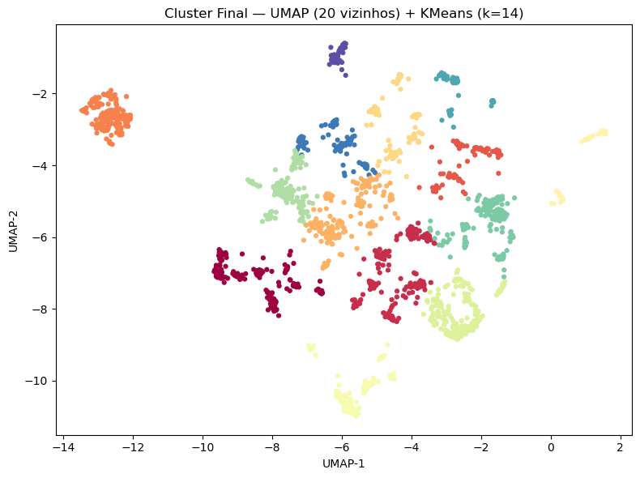

```python
# ---------------------------------------------------------
# CLUSTER FINAL — usando os valores escolhidos (n_neighbors=20, k=14)
# ---------------------------------------------------------

print("\n Gerando cluster final com n_neighbors=20 e k=14...")

best_neighbors = 20
best_k = 14

# UMAP final
reducer_final = umap.UMAP(
    n_neighbors=best_neighbors,
    n_components=2,
    min_dist=0.1,
    metric="euclidean",
    random_state=42
)

X_umap_final = reducer_final.fit_transform(X_scaled)

# KMeans final
km_final = KMeans(n_clusters=best_k, random_state=42)
final_labels = km_final.fit_predict(X_umap_final)

print("  Cluster final gerado!")

# Corrigir user_login
user_logins = cleaned["user_login"].values

# salvar arquivo final
final_df = pd.DataFrame({
    "user_login": user_logins,
    "cluster": final_labels,
    "umap_x": X_umap_final[:, 0],
    "umap_y": X_umap_final[:, 1]
})

final_path = f"{OUTPUT_DIR}/user_clusters_kmeans_final.csv"
final_df.to_csv(final_path, index=False)
print(f"  Cluster final salvo em: {final_path}")

# Plot final
plt.figure(figsize=(8, 6))
plt.scatter(
    final_df["umap_x"],
    final_df["umap_y"],
    c=final_df["cluster"],
    cmap="Spectral",
    s=12
)
plt.title("Cluster Final — UMAP (20 vizinhos) + KMeans (k=14)")
plt.xlabel("UMAP-1")
plt.ylabel("UMAP-2")
plt.tight_layout()
plt.show()

plt.savefig(f"{FIG_DIR}/umap_kmeans_final.png", dpi=300)
plt.close()
```

```python
# Imprimir o arquivo final para validação

import pandas as pd

df = pd.read_csv ("/Users/trash/Downloads/Projeto_Disciplina/Cidade_sp/processed/user_clusters_kmeans_final.csv")
print(df)
```

```
       user_login  cluster    umap_x    umap_y
0          a42147       12 -5.401861 -3.980314
1        aabeills        2 -3.344775 -4.656108
2          aargon        1 -5.598045 -7.849788
3        abnerino        4 -6.474101 -5.882765
4        abrantes        4 -6.395605 -5.962543
...           ...      ...       ...       ...
1989    zeximbico        0 -9.453322 -7.083878
1990    zihan_cai        0 -9.545488 -7.051311
1991       zilezi       12 -7.120178 -3.474925
1992       zjesko        0 -8.764569 -7.022995
1993  zoodothalis        1 -5.114062 -7.388085

[1994 rows x 4 columns]
```

```python
import pandas as pd
from pathlib import Path

print(" Carregando dados...")

# ======================
# 1️ Carregar datasets
# ======================
obs = pd.read_csv("data_filtered/observations_sao_paulo.csv")
users = pd.read_csv("/Users/trash/Downloads/Projeto_Disciplina/Cidade_sp/processed/user_clusters_kmeans_final.csv")

print(f" Observações: {len(obs)} registros")
print(f" Usuários: {len(users)} registros")

# =====================
# 2️ Identificar colunas de coordenadas
# ======================
lat_col = "latitude" if "latitude" in obs.columns else "private_latitude"
lon_col = "longitude" if "longitude" in obs.columns else "private_longitude"
print(f" Usando colunas: {lat_col}, {lon_col}")

# ======================
# 3️ Verificar e corrigir nome da coluna de cluster
# ======================
if "cluster" not in users.columns:
    alt = [c for c in users.columns if "cluster" in c.lower()][0]
    users = users.rename(columns={alt: "cluster"})

# Como é KMeans final: não existem outliers -1
print(f" Clusters válidos encontrados: {users['cluster'].nunique()}")

# ======================
# 4️ Garantir chave de merge
# ======================
if "user_login" not in users.columns:
    alt_user_col = [c for c in users.columns if "user" in c.lower()][0]
    users = users.rename(columns={alt_user_col: "user_login"})

# Renomear apenas as outras colunas (evitando renomeações duplas!)
cols_to_rename = [c for c in users.columns if c not in ["user_login", "cluster"]]
users_renamed = users.rename(columns={c: f"user_{c}" for c in cols_to_rename})

# ======================
# 5️ Merge seguro
# ======================
merged = obs.merge(users_renamed, on="user_login", how="inner")
print(f" Merge concluído: {len(merged)} observações associadas a clusters")

# ======================
# 6️ Converter coordenadas
# ======================
merged[lat_col] = pd.to_numeric(merged[lat_col], errors="coerce")
merged[lon_col] = pd.to_numeric(merged[lon_col], errors="coerce")

# ======================
# 7️ Estatísticas por cluster
# ======================
print(" Calculando estatísticas por cluster...")

def get_top_species(series, n=10):
    return ", ".join(series.value_counts().head(n).index)

cluster_summary = (
    merged.groupby("cluster")
    .agg(
        n_users=("user_login", "nunique"),
        n_obs=("id", "count"),
        top_species=("scientific_name", lambda x: get_top_species(x)),
        mean_lat=(lat_col, "mean"),
        mean_lon=(lon_col, "mean"),
    )
    .reset_index()
)

# ======================
# 8️ Salvar
# ======================
out_path = Path("processed/cluster_ecology_summary.csv")
cluster_summary.to_csv(out_path, index=False)

print(f" Resumo ecológico salvo em: {out_path}\n")
print(cluster_summary)
```

```
 Carregando dados...
 Observações: 45035 registros
 Usuários: 1994 registros
 Usando colunas: latitude, longitude
 Clusters válidos encontrados: 14
 Merge concluído: 35453 observações associadas a clusters
 Calculando estatísticas por cluster...
 Resumo ecológico salvo em: processed/cluster_ecology_summary.csv

    cluster  n_users  n_obs  \
0         0      193   1340
1         1      213   1180
2         2       97    451
3         3      187   1364
4         4      193  24510
```

[output cut: 25 more lines]

```python
import pandas as pd
import folium
from branca.colormap import linear
from matplotlib import cm, colors
from pathlib import Path

# ======================
# 1️⃣ Carregar dados
# ======================
obs_path = "data_filtered/observations_sao_paulo.csv"
users_path = "/Users/trash/Downloads/Projeto_Disciplina/Cidade_sp/processed/user_clusters_kmeans_final.csv"

obs = pd.read_csv(obs_path)
users = pd.read_csv(users_path)

# ======================
# 2️⃣ Garantir colunas corretas
# ======================
lat_col = "latitude" if "latitude" in obs.columns else "private_latitude"
lon_col = "longitude" if "longitude" in obs.columns else "private_longitude"

if "cluster" not in users.columns:
    alt = [c for c in users.columns if "cluster" in c.lower()][0]
    users = users.rename(columns={alt: "cluster"})

if "user_login" not in users.columns:
    alt_user_col = [c for c in users.columns if "user" in c.lower()][0]
    users = users.rename(columns={alt_user_col: "user_login"})

# ======================
# 3️⃣ Merge observações com clusters
# ======================
merged = obs.merge(users, on="user_login", how="inner")

# ======================
# 4️⃣ Gerar resumo por cluster (centroids)
# ======================
cluster_summary = (
    merged.groupby("cluster")
    .agg(
        n_users=("user_login", "nunique"),
        n_obs=("user_login", "count"),
        mean_lat=(lat_col, "mean"),
        mean_lon=(lon_col, "mean"),
    )
    .reset_index()
)

# ======================
# 5️ Criar mapa interativo com gradiente
# ======================
sp_center = [-23.55, -46.63]
m = folium.Map(location=sp_center, zoom_start=11)

# Colormap baseado no número de usuários
colormap = linear.YlOrRd_09.scale(cluster_summary['n_users'].min(), cluster_summary['n_users'].max())
colormap.caption = 'Número de usuários por cluster'
colormap.add_to(m)

for _, row in cluster_summary.iterrows():
    folium.CircleMarker(
        location=[row['mean_lat'], row['mean_lon']],
        radius=5 + row['n_users']*0.05,
        color=colormap(row['n_users']),
        fill=True,
        fill_opacity=0.7,
        popup=(f"Cluster: {row['cluster']}<br>"
               f"Usuários: {row['n_users']}<br>"
               f"Observações: {row['n_obs']}")
    ).add_to(m)

# Criar pasta se não existir
Path("processed").mkdir(parents=True, exist_ok=True)
map_path = "processed/cluster_centroids_gradient_map.html"
m.save(map_path)
print(f"✅ Mapa interativo salvo em: {map_path}")

# ======================
# 6️ Top espécies de cada cluster
# ======================
def get_top_species(series, n=10):
    return ", ".join(series.value_counts().head(n).index)

cluster_tops = (
    merged.groupby("cluster")
    .agg(top_species=("scientific_name", lambda x: get_top_species(x, n=10)))
    .reset_index()
)

# Salvar CSV
tops_path = "processed/cluster_top_species.csv"
cluster_tops.to_csv(tops_path, index=False)
print(f" Top espécies por cluster salvo em: {tops_path}")

# ======================
# 7️ Exibir no console
# ======================
for _, row in cluster_tops.iterrows():
    print(f"Cluster {row['cluster']}: {row['top_species']}")
```

```
✅ Mapa interativo salvo em: processed/cluster_centroids_gradient_map.html
 Top espécies por cluster salvo em: processed/cluster_top_species.csv
Cluster 0: Columba livia domestica, Cairina moschata domestica, Turdus rufiventris, Gallinula galeata, Pitangus sulphuratus, Vanellus chilensis, Coragyps atratus, Nannopterum brasilianum, Furnarius rufus, Columbina talpacoti
Cluster 1: Ardea alba, Coragyps atratus, Turdus rufiventris, Vanellus chilensis, Gallinula galeata, Dendrocygna viduata, Nannopterum brasilianum, Butorides striata, Pitangus sulphuratus, Celeus flavescens
Cluster 2: Diopsittaca nobilis, Amazona aestiva, Zenaida auriculata, Brotogeris tirica, Eupetomena macroura, Pitangus sulphuratus, Turdus rufiventris, Paroaria dominicana, Celeus flavescens, Thraupis sayaca
Cluster 3: Nannopterum brasilianum, Nycticorax nycticorax, Phimosus infuscatus, Egretta thula, Egretta caerulea, Larus dominicanus, Eudocimus ruber, Ardea alba, Turdus rufiventris, Pitangus sulphuratus
Cluster 4: Turdus rufiventris, Brotogeris tirica, Pitangus sulphuratus, Thraupis sayaca, Zenaida auriculata, Celeus flavescens, Vanellus chilensis, Turdus leucomelas, Gallinula galeata, Furnarius rufus
Cluster 5: Turdus rufiventris, Penelope obscura, Passer domesticus, Celeus flavescens, Pitangus sulphuratus, Furnarius rufus, Brotogeris tirica, Mesembrinibis cayennensis, Caracara plancus, Colaptes campestris
Cluster 6: Caracara plancus, Penelope obscura, Turdus rufiventris, Celeus flavescens, Pitangus sulphuratus, Vanellus chilensis, Coereba flaveola, Brotogeris tirica, Thraupis sayaca, Coragyps atratus
Cluster 7: Cygnus atratus, Gallinula galeata, Turdus rufiventris, Nannopterum brasilianum, Pitangus sulphuratus, Vanellus chilensis, Furnarius rufus, Ardea alba, Anser cygnoides domesticus, Brotogeris tirica
Cluster 8: Turdus rufiventris, Celeus flavescens, Pitangus sulphuratus, Piaya cayana, Brotogeris tirica, Coereba flaveola, Thraupis sayaca, Zenaida auriculata, Patagioenas picazuro, Turdus leucomelas
Cluster 9: Turdus rufiventris, Pitangus sulphuratus, Furnarius rufus, Vanellus chilensis, Gallinula galeata, Brotogeris tirica, Turdus leucomelas, Thraupis sayaca, Mimus saturninus, Nannopterum brasilianum
Cluster 10: Furnarius rufus, Mimus saturninus, Turdus rufiventris, Pitangus sulphuratus, Celeus flavescens, Brotogeris tirica, Turdus leucomelas, Zenaida auriculata, Nannopterum brasilianum, Thraupis sayaca
Cluster 11: Ramphastos dicolorus, Vanellus chilensis, Anser anser domesticus, Turdus rufiventris, Nannopterum brasilianum, Gallinula galeata, Mimus saturninus, Turdus leucomelas, Aramides saracura, Coereba flaveola
Cluster 12: Guira guira, Athene cunicularia, Mimus saturninus, Brotogeris tirica, Daptrius chimachima, Caracara plancus, Fluvicola nengeta, Turdus rufiventris, Furnarius rufus, Machetornis rixosa
Cluster 13: Ramphastos toco, Celeus flavescens, Pitangus sulphuratus, Turdus rufiventris, Ramphastos dicolorus, Brotogeris tirica, Penelope obscura, Thraupis sayaca, Mimus saturninus, Turdus leucomelas
```

**Cluster 0** — “Urbanão generalista”

Espécies-chave: Columba livia domestica, Cairina moschata domestica, Pitangus sulphuratus, Coragyps atratus Perfil ecológico:

Alta presença de espécies sinantrópicas e muito tolerantes à urbanização.

Altíssima plasticidade ecológica, forrageiam em qualquer ambiente urbano.

Representa zonas densamente urbanizadas com praças, avenidas e áreas degradadas.

**Cluster 1** — “Áreas úmidas e parques com corpos d’água”

Espécies-chave: Ardea alba, Dendrocygna viduata, Nannopterum brasilianum Perfil ecológico:

Espécies ligadas a lagos, represas, canais e várzeas.

Presença de garças, biguás e marrecos sugere ambientes com água permanente.

Representa parques como Ibirapuera, Água Branca, Vila-Lobos, Billings/Guarapiranga.

**Cluster 2** — “Floresta urbana / Mata secundária”

Espécies-chave: Amazona aestiva, Diopsittaca nobilis, Brotogeris tirica Perfil ecológico:

Papagaios e periquitos indicam ambientes arborizados extensos, fragmentos e parques com mata fechada.

Preferência por copas altas, áreas ricas em árvores frutíferas.

Próximo a parques grandes (Cantareira, Horto, USP, Jardins).

**Cluster 3** — “Ambientes aquáticos abertos / várzeas grandes”

Espécies-chave: Nannopterum brasilianum, Egretta thula, Larus dominicanus Perfil ecológico:

Forte associação com represas grandes e corpos d’água mais abertos.

Biguás + gaivotas sugerem até ambiente semi-estuarino ou grande alagado.

Representa Guarapiranga, Billings, Tietê em trechos com grandes espelhos d’água.

**Cluster 4** — “Matriz urbana mista / jardins residenciais”

Espécies-chave: Turdus rufiventris, Thraupis sayaca, Brotogeris tirica Perfil ecológico:

Espécies semi-generalistas, comuns em quintais, parques, ruas arborizadas.

Indica zonas residenciais e bairros com boa arborização.

Muito típico de zona oeste e sul mais urbanizada.

**Cluster 5** — “Mata mais densa / interior de parques”

Espécies-chave: Penelope obscura, Mesembrinibis cayennensis Perfil ecológico:

Indica floresta secundária mais conservada.

Representa Cantareira, Parelheiros, reservas municipais.

**Cluster 6** — “Campos abertos e bordas”

Espécies-chave: Caracara plancus, Penelope obscura, Thraupis sayaca Perfil ecológico:

Indica bordas de mata, campos alterados, áreas periurbanas.

Muitas espécies tolerantes, mas que requerem algum grau de vegetação.

**Cluster 7** — “Parques com lagos ornamentais / fauna exótica”

Espécies-chave: Cygnus atratus (cisne negro), Anser cygnoides domesticus Perfil ecológico:

Forte presença de espécies exóticas ornamentais → parques urbanos com lagos artificiais.

Mistura entre aves aquáticas e generalistas.

Representa Ibirapuera, Parque da Aclimação, Parque do Carmo.

**Cluster 8** — “Bordas, matas secundárias e áreas de transição”

Espécies-chave: Piaya cayana, Patagioenas picazuro Perfil ecológico:

Espécies de sub-bosque e bordas florestais.

Ambientes de transição entre urbano e mata.

Indica zonas verdes intermediárias (ex.: USP, parques médios).

**Cluster 9** — “Urbano arborizado comum”

Espécies-chave: Pitangus sulphuratus, Turdus leucomelas, Mimus saturninus Perfil ecológico:

Similar ao cluster 4, mas mais “onde o paulistano vive”.

Espécies altamente ubiquistas, típicas de bairros com árvores.

Bom indicativo de áreas residenciais de média densidade.

**Cluster 10** — “Áreas de vegetação aberta e jardins amplos”

Espécies-chave: Mimus saturninus, Celeus flavescens Perfil ecológico:

Ambientes semiabertos, com árvores isoladas.

Parques menores, praças e bairros mais abertos.

**Cluster 11** — “Mata úmida + grandes árvores frutíferas”

Espécies-chave: Ramphastos dicolorus, Aramides saracura Perfil ecológico:

Indica matas úmidas, interior de parques grandes, vales sombreados.

Forte associação com floresta secundária de boa qualidade.

**Cluster 12** — “Bordas secas, campos e áreas mais abertas”

Espécies-chave: Guira guira, Athene cunicularia Perfil ecológico:

Campo aberto, gramados amplos, bordas secas.

Muito típico de áreas mais planas, clubes, campos esportivos.

**Cluster 13** — “Floresta bem estruturada / Mata densa”

Espécies-chave: Ramphastos toco, Ramphastos dicolorus, Penelope obscura Perfil ecológico:

Espécies tipicamente associadas a matas maduras ou secundárias avançadas.

Representa os principais remanescentes florestais da metrópole.

[output not shown]

```python
import pandas as pd
import folium
from branca.colormap import linear
from pathlib import Path

# ======================
# 1️ Carregar dados
# ======================
obs_path = "data_filtered/observations_sao_paulo.csv"
users_path = "/Users/trash/Downloads/Projeto_Disciplina/processed/user_clusters_kmeans_final.csv"

obs = pd.read_csv(obs_path)
users = pd.read_csv(users_path)

# ======================
# 2️ Garantir colunas corretas
# ======================
lat_col = "latitude" if "latitude" in obs.columns else "private_latitude"
lon_col = "longitude" if "longitude" in obs.columns else "private_longitude"

if "cluster" not in users.columns:
    alt = [c for c in users.columns if "cluster" in c.lower()][0]
    users = users.rename(columns={alt: "cluster"})

if "user_login" not in users.columns:
    alt_user_col = [c for c in users.columns if "user" in c.lower()][0]
    users = users.rename(columns={alt_user_col: "user_login"})

# ======================
# 3️ Merge observações com clusters
# ======================
merged = obs.merge(users, on="user_login", how="inner")

# ======================
# 4️ Resumo por cluster (centroides)
# ======================
cluster_summary = (
    merged.groupby("cluster")
    .agg(
        n_users=("user_login", "nunique"),
        n_obs=("user_login", "count"),
        mean_lat=(lat_col, "mean"),
        mean_lon=(lon_col, "mean"),
    )
    .reset_index()
)

# ======================
# 5️ Criar mapa interativo com gradiente
# ======================
sp_center = [-23.55, -46.63]
m = folium.Map(location=sp_center, zoom_start=11)

colormap = linear.YlOrRd_09.scale(cluster_summary['n_users'].min(), cluster_summary['n_users'].max())
colormap.caption = 'Número de usuários por cluster'
colormap.add_to(m)

for _, row in cluster_summary.iterrows():
    folium.CircleMarker(
        location=[row['mean_lat'], row['mean_lon']],
        radius=5 + row['n_users']*0.05,
        color=colormap(row['n_users']),
        fill=True,
        fill_opacity=0.7,
        popup=(f"Cluster: {row['cluster']}<br>"
               f"Usuários: {row['n_users']}<br>"
               f"Observações: {row['n_obs']}")
    ).add_to(m)

Path("processed").mkdir(parents=True, exist_ok=True)
map_path = "processed/cluster_centroids_gradient_map.html"
m.save(map_path)
print(f" Mapa interativo salvo em: {map_path}")

# ======================
# 6️ Listar TODAS as espécies por cluster
# ======================
species_by_cluster = (
    merged.groupby("cluster")["scientific_name"]
    .apply(lambda x: sorted(x.unique()))
    .reset_index()
    .rename(columns={"scientific_name": "all_species"})
)

# Salvar CSV com todas as espécies
all_species_path = "processed/cluster_all_species.csv"
species_by_cluster.to_csv(all_species_path, index=False)
print(f" Lista completa de espécies por cluster salva em: {all_species_path}")

# ======================
# 7️ Top 10 espécies por cluster
# ======================
def get_top_species(series, n=10):
    return ", ".join(series.value_counts().head(n).index)

cluster_tops = (
    merged.groupby("cluster")
    .agg(top_species=("scientific_name", lambda x: get_top_species(x, n=10)))
    .reset_index()
)

tops_path = "processed/cluster_top_species.csv"
cluster_tops.to_csv(tops_path, index=False)
print(f" Top espécies por cluster salvo em: {tops_path}")

# ======================
# 8️ Exibir TODAS as espécies de cada cluster no console
# ======================
for _, row in species_by_cluster.iterrows():
    print(f"\n" + "="*50)
    print(f"Cluster {row['cluster']} - Total espécies: {len(row['all_species'])}")
    print("="*50)

    # Imprimir todas as espécies, uma por linha
    for i, especie in enumerate(row['all_species'], 1):
        print(f"{i:3d}. {especie}")
```

```
 Mapa interativo salvo em: processed/cluster_centroids_gradient_map.html
 Lista completa de espécies por cluster salva em: processed/cluster_all_species.csv
 Top espécies por cluster salvo em: processed/cluster_top_species.csv

==================================================
Cluster 0 - Total espécies: 157
==================================================
  1. Accipiter striatus
  2. Alopochen aegyptiaca
  3. Amazona aestiva
  4. Amazonetta brasiliensis
  5. Anhinga anhinga
  6. Anser
  7. Anser anser
  8. Anser anser domesticus
  9. Anser anser domesticus × cygnoides domesticus
 10. Anser anser × cygnoides
 11. Anser cygnoides domesticus
 12. Aramides
 13. Aramides saracura
 14. Aramus guarauna
 15. Ardea
 16. Ardea alba
 17. Ardea alba × cocoi
 18. Ardea cocoi
 19. Ardea ibis
 20. Ardeinae
 21. Asio clamator
 22. Attila rufus
 23. Basileuterus culicivorus
 24. Brotogeris tirica
 25. Butorides striata
 26. Cairina moschata
 27. Cairina moschata domestica
 28. Camptostoma obsoletum
 29. Caracara plancus
 30. Cariama cristata
 31. Celeus flavescens
 32. Chiroxiphia caudata
 33. Chlorostilbon lucidus
```

[output cut: 2455 more lines]

```
 99. Trochilini
100. Troglodytes musculus
101. Trogon surrucura
102. Turdus
103. Turdus amaurochalinus
104. Turdus leucomelas
105. Turdus rufiventris
106. Tyrannus melancholicus
107. Tyrannus savana
108. Tyto furcata tuidara
109. Vanellus chilensis
110. Vireo chivi
111. Xiphorhynchus fuscus
112. Zenaida auriculata
113. Zonotrichia capensis
```

```python
import pandas as pd
import folium
from folium.plugins import MarkerCluster
from pathlib import Path
from branca.colormap import linear

# ======================
# 1️ Carregar dados
# ======================
obs = pd.read_csv("data_filtered/observations_sao_paulo.csv")
users = pd.read_csv("/Users/trash/Downloads/Projeto_Disciplina/Cidade_sp/processed/user_clusters_kmeans_final.csv")

# =====================
# 2️ Garantir colunas corretas
# ======================
lat_col = "latitude" if "latitude" in obs.columns else "private_latitude"
lon_col = "longitude" if "longitude" in obs.columns else "private_longitude"

if "cluster" not in users.columns:
    alt = [c for c in users.columns if "cluster" in c.lower()][0]
    users = users.rename(columns={alt: "cluster"})

if "user_login" not in users.columns:
    alt_user_col = [c for c in users.columns if "user" in c.lower()][0]
    users = users.rename(columns={alt_user_col: "user_login"})

# ======================
# 3️ Merge observações com clusters
# ======================
merged = obs.merge(users, on="user_login", how="inner")

# ======================
# 4️ Atribuir perfis ecológicos aos clusters
# ======================
cluster_profiles = {
    0: "Urbano duro / sinantrópicos",
    1: "Ambientes aquáticos",
    2: "Mata / fragmentos florestais",
    3: "Ambientes aquáticos",
    4: "Urbano arborizado / quintais",
    5: "Mata / fragmentos florestais",
    6: "Campos abertos",
    7: "Urbano duro / sinantrópicos",
    8: "Mata / fragmentos florestais",
    9: "Urbano arborizado / quintais",
    10: "Urbano arborizado / quintais",
    11: "Mata / fragmentos florestais",
    12: "Campos abertos",
    13: "Mata / fragmentos florestais"
}

merged['ecoprofile'] = merged['cluster'].map(cluster_profiles)

# ======================
# 5️ Resumo por cluster
# ======================
cluster_summary = (
    merged.groupby(['cluster', 'ecoprofile'])
    .agg(
        n_users=("user_login", "nunique"),
        n_obs=("user_login", "count"),
        mean_lat=(lat_col, "mean"),
        mean_lon=(lon_col, "mean")
    ).reset_index()
)

# ======================
# 6️ Criar mapa temático por perfil ecológico
# ======================
sp_center = [-23.55, -46.63]
m = folium.Map(location=sp_center, zoom_start=11)

# Cores por perfil
profile_colors = {
    "Urbano duro / sinantrópicos": "red",
    "Urbano arborizado / quintais": "green",
    "Ambientes aquáticos": "blue",
    "Mata / fragmentos florestais": "darkgreen",
    "Campos abertos": "orange"
}

for _, row in cluster_summary.iterrows():
    folium.CircleMarker(
        location=[row['mean_lat'], row['mean_lon']],
        radius=5 + row['n_users']*0.05,
        color=profile_colors[row['ecoprofile']],
        fill=True,
        fill_opacity=0.7,
        popup=(f"Cluster: {row['cluster']}<br>"
               f"Perfil ecológico: {row['ecoprofile']}<br>"
               f"Usuários: {row['n_users']}<br>"
               f"Observações: {row['n_obs']}")
    ).add_to(m)

# ======================
# 7️ Salvar mapa
# ======================
Path("processed").mkdir(parents=True, exist_ok=True)
map_path = "processed/cluster_ecoprofile_map.html"
m.save(map_path)
print(f" Mapa temático por perfil ecológico salvo em: {map_path}")

# ======================
# 8️ Salvar tabela resumo CSV
# ======================
summary_path = "processed/cluster_ecoprofile_summary.csv"
cluster_summary.to_csv(summary_path, index=False)
print(f" Tabela resumo por cluster e perfil ecológico salva em: {summary_path}")
```

```
 Mapa temático por perfil ecológico salvo em: processed/cluster_ecoprofile_map.html
 Tabela resumo por cluster e perfil ecológico salva em: processed/cluster_ecoprofile_summary.csv
```

```python
import pandas as pd

df = pd.read_csv ("processed/cluster_ecoprofile_summary.csv")
print(df)
```

```
    cluster                    ecoprofile  n_users  n_obs   mean_lat  \
0         0   Urbano duro / sinantrópicos      193   1340 -23.563875
1         1           Ambientes aquáticos      213   1180 -23.610199
2         2  Mata / fragmentos florestais       97    451 -23.582984
3         3           Ambientes aquáticos      187   1364 -23.914616
4         4  Urbano arborizado / quintais      193  24510 -23.603805
5         5  Mata / fragmentos florestais      134   1791 -23.587251
6         6                Campos abertos       62    113 -23.559408
7         7   Urbano duro / sinantrópicos      152   1350 -23.579640
8         8  Mata / fragmentos florestais      192    295 -23.568012
9         9  Urbano arborizado / quintais      162   1098 -23.573058
10       10  Urbano arborizado / quintais      172    328 -23.580133
11       11  Mata / fragmentos florestais       75    239 -23.629532
12       12                Campos abertos       97    912 -23.521395
13       13  Mata / fragmentos florestais       65    482 -23.588970
```

[output cut: 16 more lines]

# O mapa interativo que você gerou mostra a distribuição geográfica dos clusters de usuários em São Paulo. Cada ponto representa uma observação feita por um usuário, e a cor do ponto indica a qual cluster de comportamento/ecológico aquele usuário pertence.

- Alguns detalhes importantes:

Cores diferentes para clusters: ajudam a identificar visualmente quais áreas têm maior concentração de usuários de cada grupo.

MarkerCluster: pontos próximos se agrupam automaticamente, evitando sobreposição e facilitando a visualização de regiões densamente povoadas.

Popup interativo: ao clicar em cada ponto, é possível ver informações sobre o usuário, o cluster e a espécie observada.

```python
import os
import pandas as pd
import folium
from folium.plugins import MarkerCluster
from matplotlib import cm, colors

# ============================================================
# CONFIGURAÇÕES
# ============================================================
BASE_DIR = "/Users/trash/Downloads/Projeto_Disciplina/Cidade_sp"
OBS_FILE = os.path.join(BASE_DIR, "data_filtered/observations_sao_paulo.csv")
CLUSTER_FILE = os.path.join(BASE_DIR, "processed/user_clusters_kmeans_final.csv")

OUTPUT_MAP_DIR = os.path.join(BASE_DIR, "processed", "maps")
os.makedirs(OUTPUT_MAP_DIR, exist_ok=True)

# ============================================================
# 1️ CARREGAR DADOS
# ============================================================
obs = pd.read_csv(OBS_FILE)
clusters = pd.read_csv(CLUSTER_FILE)

# Garantir nomes das colunas
lat_col = "latitude" if "latitude" in obs.columns else "private_latitude"
lon_col = "longitude" if "longitude" in obs.columns else "private_longitude"

if "cluster" not in clusters.columns:
    alt = [c for c in clusters.columns if "cluster" in c.lower()][0]
    clusters = clusters.rename(columns={alt: "cluster"})

if "user_login" not in clusters.columns:
    alt_user = [c for c in clusters.columns if "user" in c.lower()][0]
    clusters = clusters.rename(columns={alt_user: "user_login"})

# Merge observações com clusters
df = obs.merge(clusters, on="user_login", how="inner")

# ============================================================
# 2️ CRIAR MAPA INTERATIVO
# ============================================================
sp_center = [-23.55, -46.63]
m = folium.Map(location=sp_center, zoom_start=11)

# Gerar cores para cada cluster
n_clusters = df["cluster"].nunique()
cmap = cm.get_cmap("tab20", n_clusters)
cluster_colors = {i: colors.rgb2hex(cmap(i)) for i in sorted(df["cluster"].unique())}

# Adicionar pontos com MarkerCluster
marker_cluster = MarkerCluster().add_to(m)
for _, row in df.iterrows():
    folium.CircleMarker(
        location=[row[lat_col], row[lon_col]],
        radius=4,
        color=cluster_colors[row["cluster"]],
        fill=True,
        fill_opacity=0.7,
        popup=f"Cluster: {row['cluster']}<br>User: {row['user_login']}<br>Species: {row['scientific_name']}"
    ).add_to(marker_cluster)

# ============================================================
# 3️ SALVAR MAPA
# ============================================================
map_file = os.path.join(OUTPUT_MAP_DIR, "cluster_map_interactive_kmeans.html")
m.save(map_file)
print(f" Mapa interativo salvo em: {map_file}")
```

```
 Mapa interativo salvo em: /Users/trash/Downloads/Projeto_Disciplina/Cidade_sp/processed/maps/cluster_map_interactive_kmeans.html
```